# CHAPTER A-17

# BENDING OF PLATES

ALFRED F. SCHMITT

### A17.1 導入

前章で見たように、薄い曲面シェルは引張圧縮の膜応力によって横荷重に耐えることができる。後述するように、薄い平板もまた、必要な曲率と伸びの両方を提供するのに十分なだけたわむことによって、横荷重を支持するための膜応力を発生させることがある。これらの状況の解析においては、板に曲げ強さは仮定されない（膜理論）。

膜とは対照的に、板は梁の二次元の対応物であり、横荷重は曲げ応力と剪断応力によって抵抗され、その中立面（中立面）には直接応力は生じない。

外皮はまた、荷重下での横たわみの大きさに応じて、板または膜のいずれかに分類される。板の横たわみは、板の厚さに比べて小さく、厚さの10分の1のオーダーである。一方、膜の横たわみは、その厚さの10倍のオーダーになる。*

*後述するように、膜応力の有無は、たわみの大きさだけに依存するのではなく、板によって想定されるたわみ面の形状（ひいては境界の形状と荷重に依存する）によっても決定される。

技術者が問題を秩序正しく分類しようとする試みにとって不運なことに、ほとんどの航空機の外皮は上記2つの極端なケースの中間に位置するため、いくらかの膜応力を有する板として振る舞う。

板の曲げ調査は、航空機の構造解析において、シートの座屈問題との関連で古くから重要視されてきた。最近では、厚肉外皮構造の導入に伴い、またさらに最近では、大型の板のように振る舞う、あるいは場合によっては板そのものである非常に薄い低アスペクト比の翼や制御面の使用に伴い、新たな重要性を帯びてきている。

本章の目的は、古典的な板の公式とそのいくつかの応用を簡潔に提示することである。この主題に関する膨大な文献が示すように、1つの章（あるいは1つの巻）では到底提示しきれない網羅的な論文の代わりに、適切な参考文献を引用する。

### A17.2 板の曲げ方程式**

**以下の解析に暗黙的に含まれる仮定は、以下のArt. A17.5において詳細に説明されている。

この分野の技術文献には、板の曲げ方程式の優れたエレガントな誘導が数多く存在する（例えば、参考文献1および2）。この主題に骨を折るよりも、別のものを用いて、過去の経験と直感に直接訴えかけることによって方程式を書き下すことにする。

Fig. A17.1は、薄い初期に平坦な板の微小要素を示しており、それぞれ $y$ および $x$ 方向に平行な軸のまわりの（単位長さあたりの）曲げモーメント $M_x$ および $M_y$ が作用している。ねじりモーメントの組 $M_{xy}$ ( $= - M_{yx}$ ) もまた要素に作用している。

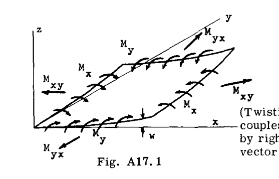

Fig. A17.1

梁の場合と同様に、 $x, z$ 面における曲率 $\partial^2 w / \partial x^2$ は、加えられたモーメント $M_x$ に比例する。比例定数は曲げ剛性の逆数である $1/EI$ である。梁の単位幅に対して $I = t^3/12$ である。板の場合、ポアソン効果により、モーメント $M_y$ もまた $x, z$ 面に（負の）曲率を生じさせる。したがって、両方のモーメントが作用する場合、総合すると次のようになる。

$$\frac{\partial^2 w}{\partial x^2} = \frac{12}{E t^3} (M_x - \mu M_y)$$

ここで $\mu$ はポアソン比である（アルミニウムでは約0.3）。同様に、 $y, z$ 面における曲率は次のようになる。

$$\frac{\partial^2 w}{\partial y^2} = \frac{12}{E t^3} (M_y - \mu M_x)$$

これら2つの方程式は、通常、曲率を用いてモーメントを表すように再整理される。これらは次のように書かれる。

$$M_x = D \left( \frac{\partial^2 w}{\partial x^2} + \mu \frac{\partial^2 w}{\partial y^2} \right) \quad \text{--- (1)}$$

$$M_y = D \left( \frac{\partial^2 w}{\partial y^2} + \mu \frac{\partial^2 w}{\partial x^2} \right) \quad \text{--- (2)}$$

ここで

$$D = E t^3 / 12(1 - \mu^2)$$

要素のねじれ $\partial^2 w / \partial x \partial y$ ( $= \partial^2 w / \partial y \partial x$ ) は、 $y$ 方向の単位距離あたりの $x$ 方向の傾きの変化である（またその逆も同様である）***。

***たわみ関数 $w$ が $x$ と $y$ の連続関数である場合（技術的に重要な板の問題では当然そうであるはずだが）、微積分で証明されているように、各点において $\partial^2 w / \partial x \partial y = \partial^2 w / \partial y \partial x$ となる。

これはねじりモーメント $M_{xy}$ に比例する。慎重な解析（参考文献1および2を参照）により、以下の関係が得られる。

$$M_{xy} = D(1 - \mu) \frac{\partial^2 w}{\partial x \partial y} \quad \text{--- (3)}$$

方程式(1)、(2)および(3)は、梁における $M = EI d^2y/dx^2$ とほぼ同様に、加えられた曲げおよびねじりモーメントを板の歪みに関連付けている。

これらの方程式を用いていくつかの非常に有益な問題を解決できるが（参考文献1のpp. 45-49および参考文献2のpp. 111-113を参照）、それらは技術的な重要性はほとんどない。したがって、横荷重による曲げの検討に進む。

Fig. A17.2は、Fig. A17.1と同じ板要素を示しているが、内部剪断力 $Q_x$ および $Q_y$ （梁理論の " $V$ " に対応）と分布横圧力荷重 $q$ (psi) が追加されている。これらの剪断力の存在により、曲げおよびねじりモーメントは、Fig. A17.2aに示すように、板に沿って変化する。（明確にするために、板要素に作用するいくつかの力システムは、Fig. A17.2の2つの図に分離された。もちろん、これらはすべて単一の要素に同時に作用している。）

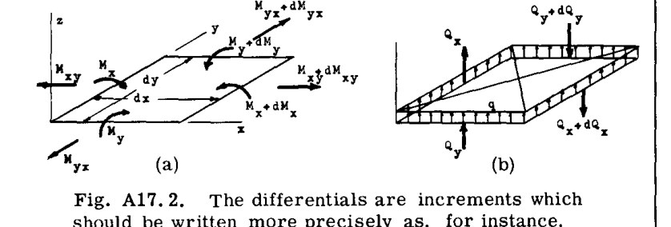

Fig. A17.2

次の関係は、 $x$ 軸および $y$ 軸のまわりのモーメントを順次足し合わせることによって得られる。例えば、Fig. A17.2の2つの荷重セットが単一の要素に同時に作用していることを視覚化し、 $y$ 軸のまわりのモーメントを足し合わせる。

$$M_x dy + (M_{yx} + dM_{yx}) dx + (Q_x + dQ_x) dx dy = (M_x + dM_x) dy + M_{yx} dx$$

$dx dy$ で割り、高次の項を破棄すると、次のようになる。

$$Q_x = \frac{\partial M_x}{\partial x} - \frac{\partial M_{yx}}{\partial y}$$

または、

$$Q_x = \frac{\partial M_x}{\partial x} + \frac{\partial M_{xy}}{\partial y} \quad \text{--- (4)}$$

同様に、 $x$ 軸まわりのモーメントの和から次が得られる。

$$Q_y = \frac{\partial M_y}{\partial y} + \frac{\partial M_{xy}}{\partial x} \quad \text{--- (5)}$$

（方程式(4)および(5)は、梁理論における $V = dM/dx$ に対応する）。

最後の1つの方程式は、要素上の $z$ 方向の力を足し合わせることによって得られる。

$$q = \frac{\partial Q_x}{\partial x} + \frac{\partial Q_y}{\partial y} \quad \text{--- (6)}$$

方程式(4)、(5)および(6)は、3つの追加の物理量 $Q_x, Q_y$ および $q$ における3つの追加の方程式を提供する。これにより、板の問題は完全に定義される。

要約するために、上記で得られた物理量と方程式を以下に表にする。比較のために、梁の工学理論からの対応する項目もリストされている。

[output not shown]

最後に、これら6つの方程式からすべての内部力（ $M_x, M_y, M_{xy}, Q_x, Q_y$ ）を消去することによって、1つの非常に重要な方程式が得られる。その結果（学生が演習として自身で得るべきものである）は、横荷重 $q$ とたわみ $w$ の間の関係である*。

$$\frac{\partial^4 w}{\partial x^4} + 2 \frac{\partial^4 w}{\partial x^2 \partial y^2} + \frac{\partial^4 w}{\partial y^4} = \frac{q}{D} \quad \text{--- (7)}$$

*単純支持梁の対応する方程式は $q/EI = d^4y/dx^4$ である。

板の曲げ問題は、このように方程式(7)の積分に帰着される。与えられた横荷重 $q(x, y)$ に対して、方程式(7)と指定された境界条件の両方を満足するたわみ関数 $w(x, y)$ が求められる。一旦見つかれば、 $w(x, y)$ を方程式(1)から(5)に代入して、内部力と応力を決定することができる。

### A17.3 板の曲げ解析の例示

すべての辺が単純支持（ヒンジ）された矩形板に横荷重が加えられたと仮定する。座標はFig. A17.3のように選択される。結果の一般的な有用性を予知して、次の形式の正弦波荷重を仮定する。

$$q = q_{mn} \sin \frac{m \pi x}{a} \sin \frac{n \pi y}{b} \quad \text{--- (8)}$$

$$m, n = 1, 2, 3, \dots$$

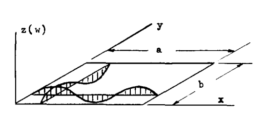

Fig. A17.3

板の得られるたわみ形状を見つけるために、次の形式の解を試みる。

$$w = A_{mn} \sin \frac{m \pi x}{a} \sin \frac{n \pi y}{b} \quad \text{--- (9)}$$

ここで $A_{mn}$ は未知のたわみ振幅である。この試行たわみ関数は、 $x = 0, a$ および $y = 0, b$ において、以下を有するため、板の境界条件を満たすことが知られている。

$$w = 0 \quad \text{（支持された端部でのたわみゼロ）}$$

$$\frac{\partial^2 w}{\partial x^2} = \frac{\partial^2 w}{\partial y^2} = 0 \quad \text{（ヒンジ端でのモーメントゼロ：式1および2を参照）}$$

方程式(7)を満たす $A_{mn}$ の値を見つけることだけが残されている。方程式(8)と(9)を(7)に代入すると、次が得られる*。

$$A_{mn} \frac{m^4 \pi^4}{a^4} + 2 A_{mn} \frac{m^2 \pi^2}{a^2} \frac{n^2 \pi^2}{b^2} + A_{mn} \frac{n^4 \pi^4}{b^4} = q_{mn} / D$$

*共通因子 $\sin \frac{m \pi x}{a} \sin \frac{n \pi y}{b}$ は除外されている。

または、

$$A_{mn} = \frac{q_{mn}}{D \pi^4 \left( \frac{m^2}{a^2} + \frac{n^2}{b^2} \right)^2}$$

したがって、必要なたわみ面（および問題の解**）は、次の式を持つ。

$$w = \frac{q_{mn}}{D \pi^4 \left( \frac{m^2}{a^2} + \frac{n^2}{b^2} \right)^2} \sin \frac{m \pi x}{a} \sin \frac{n \pi y}{b} \quad \text{--- (10)}$$

**式(7)の形式の微分方程式に対する解の一意性は、数学および数理物理学の多数の上級テキストに登場する古典的な証明である。方程式は一意の解を持つことが知られているため、それに対して見つかった任意の解は、唯一の正しい解である。

最大たわみは、三角関数が1の値を取り、 $q$ も最大となる場所で発生することがわかる。

方程式(10)を方程式(1)、(2)および(3)に代入すると、次が得られる。

$$M_x = \frac{q_{mn}}{\pi^2 \left( \frac{m^2}{a^2} + \frac{n^2}{b^2} \right)^2} \left( \frac{m^2}{a^2} + \mu \frac{n^2}{b^2} \right) \sin \frac{m \pi x}{a} \sin \frac{n \pi y}{b}$$

$$M_y = \frac{q_{mn}}{\pi^2 \left( \frac{m^2}{a^2} + \frac{n^2}{b^2} \right)^2} \left( \mu \frac{m^2}{a^2} + \frac{n^2}{b^2} \right) \sin \frac{m \pi x}{a} \sin \frac{n \pi y}{b}$$

$$M_{xy} = \frac{q_{mn} (1 - \mu)}{\pi^2 \left( \frac{m^2}{a^2} + \frac{n^2}{b^2} \right)^2} \frac{mn}{ab} \cos \frac{m \pi x}{a} \cos \frac{n \pi y}{b}$$

同様に、横剪断力は方程式(4)および(5)から求めることができる。

このような結果を用いて、必要に応じて板の応力を決定することができる。例えば、最大直接曲げ応力は、剪断応力（ $M_{xy}$ によるもの）がゼロである場所で発生することがわかる。したがって、

$$s_x \left( = \frac{MC}{I} \right) = \frac{M_x t}{2I} = \frac{6 M_x}{t^2}$$

であり、したがって、

$$s_{X\text{MAX}} = \frac{6 q_{mn}}{t^2 \pi^2} \frac{\left( \frac{m^2}{a^2} + \mu \frac{n^2}{b^2} \right)}{\left( \frac{m^2}{a^2} + \frac{n^2}{b^2} \right)^2} \quad \text{--- (11)}$$

フーリエ級数法に精通している読者は、上記の解析が、同じ板上の任意の一般的な荷重 $q(x, y)$ の問題の解決への鍵を提供することをすぐに認識するであろう。そのような応用は、その合計が所望の荷重を密接に表すように、正弦波圧力項（それぞれ式8の形式）の適切な組み合わせを決定することによって行われる。対応データたわみ関数（それぞれ式10の形式）の合計が所望の解を与える。このタイプの解析の詳細は、参考文献1のpp. 113-176および199-256に見られる。

偏微分方程式の観点から定式化されるすべての問題に共通して、板の曲げ問題の解決は、境界条件（境界の形状とそこで提供される支持のタイプの両方）に強く依存する。上記の例は、境界の単純な形状と支持のタイプの両方の理由から、欺瞞的に容易であったと言える。板の平面形状が単純な幾何学的図形ではない板の問題は、数値的方法によって解決されなければならない。支持のタイプに関しては、板の境界条件の完全な議論は、参考文献1のpp. 89-95に見られる。

### A17.4 板の曲げ問題の結果の編集

幸いなことに、実務の技術者にとって、実用的な板の問題の大部分について、上記で議論したような解析的計算を実行する必要はない。上に例示したタイプの問題と、それに伴う無数のバリエーションは、1811年のラグランジュによる式(7)の発見に続いて、数学者の間で非常にファッショナブルな演習となった。多くの研究者の努力の結果は、便利な参照のために様々な形で編集されている。

一般的で重要なケースは、一様に荷重された矩形板のケースである（Fig. A17.4）。主要な工学的結果は、発生する最大たわみと最大応力の値である。これらは以下の形式に置くことができる（ $a$ は短い辺の長さである）：

$$w_{\text{MAX}} = \alpha \frac{q a^4}{E t^3} \quad \text{--- (12)}$$

$$s_{\text{MAX}} = \beta \frac{q a^2}{t^2} \quad \text{--- (13)}$$

ここで、係数 $\alpha$ および $\beta$ は、4つの最も一般的な端部条件について、Table A17.1に与えられている。

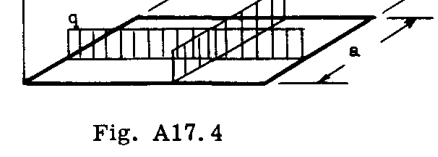

Fig. A17.4

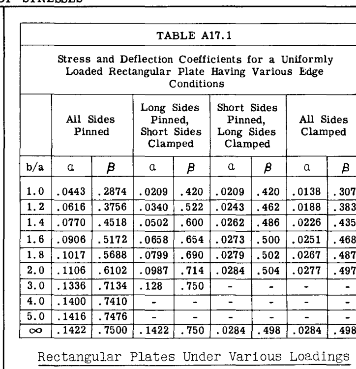

Table A17.1

様々な荷重下の矩形板： - S. Timoshenko, “Theory of Plates and Shells”, pp. 113-176, 199-256. - J. P. Den Hartog, “Advanced Strength of Materials”, pp. 132-134. - R. J. Roark, “Formulas for Stress and Strain”, pp. 202-207.

様々な荷重下の円板（順に同じ3つの参考文献）： - pp. 55-84, 257-287. - pp. 128-132. - pp. 194-201, 209-211.

同様の提示は、他の何十ものケースについても行うことができる。目的のために専用の参考文献にこれらの問題の包括的なカタログが容易に利用できるため、ここで重複させる価値はほとんどないようである。したがって、選択された参考文献の以下のリストを提示する。これらの著作物の中にも、さらなる参考文献が見られる。板の曲げ問題の線形性により、これらの広範なリストの有用性をさらに拡張するために、解の重ね合わせが可能であることに注意する。

### A17.5 板解析におけるたわみの制限

本章の導入の言葉において、板は、そのたわみの小ささ（厚さの数分の1のオーダー）によって膜と区別され得ると述べた。ここでは、この記述を再検討し、これが定義というよりも、板解析で行われた仮定の1つによって課される精度の制限であることを示す。

梁の理論からいくつかのよく知られた仮定があり、板の解析は梁の解析と非常に密接に類似しているため、当然ここにも引き継がれる。これらの「梁理論の仮定」は以下の通りである：

1. 弾性応力のみが想定される。
2. 傾きが小さい（したがって $\partial^2 w / \partial x^2$ および $\partial^2 w / \partial y^2$ は曲率の良好な近似である）。
3. 剪断変形が無視できるように、少なくとも1つの横方向の寸法（長さまたは幅）が厚さに比べて大きい。

しかし、梁理論の仮定は、許容されるたわみの大きさに対して非常に厳しい制限を課すものではない。これらが唯一の制限的な仮定であるならば、板の厚さの数倍のたわみが許容されるであろう。

板の曲げ方程式を誘導する際、板の中立（中立）面には応力が作用しない（膜応力がない）と仮定された。したがって、式(6)を誘導するために力を足し合わせる際、横荷重を支持するのを助ける膜応力は存在しなかった。現在、板の曲げ問題の大部分の解（Art. A17.3のように解かれる）において、見出されるたわみ面解は、非可展面、すなわち、シートの中立面のいくらかの伸びなしには平坦なシートから形成できない面である*。

*円錐と円柱は可展面の例であり、球は非可展面である。オレンジの皮は裂くことなしに平坦なシートに展開できないことは、よく知られた経験である。

しかし、顕著な中立面ひずみが発生しなければならない場合、大きな中立面応力が発生し、式(6)が誘導された基礎となる仮定が無効になる。

したがって、実質的にすべての荷重された板は、ある程度の中立面応力を誘発する面に変形する。これらの非常に強力な中立面伸長力の大きさを抑える必要性があるため、板の曲げ公式はたわみが板の厚さの数分の1である問題にのみ正確に適用されるという、より厳しい経験則的な制限が生じるのである。

### A17.6 非常に薄い板における膜作用

板における中立面ひずみの原因は、もう1つ存在する。それは、端部支持によって提供される面内運動に対する拘束である。前条の制限に従ってたわみが制限されている問題では重要ではないが、このような拘束は、荷重の主要な部分を膜作用によって支持する非常に薄い板の大きなたわみの場合に、非常に大きな重要性を持つ。実際、曲げ応力によって横荷重を一切支持できず、したがって必要な曲率と膜応力の両方を発生させるためにたわんで伸びなければならない、平坦な膜の極限状態を考慮することは有用である。

二次元の膜問題は非線形であり、その解決は非常に困難であることが証明されている。完全な問題を処理しようとするよりも、その解が望ましい一般的な特徴を保持している単純化されたバージョンを研究することができる。狭い（単位幅の）ストリップの一次元解析を処理する。このストリップは、 $y$ 方向の範囲が非常に大きい、元々は平坦な膜から切り出される（Fig. A17.5a）。

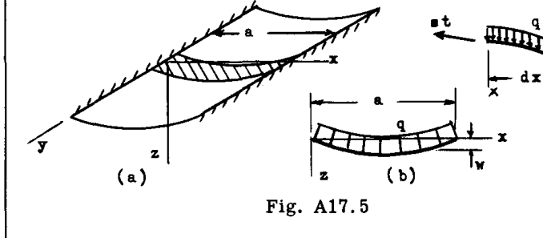

Fig. A17.5

Fig. A17.5bは、荷重されたケーブルに類似した、望ましい一次元問題を示している。平衡の微分方程式は、Fig. A17.5cの要素上の垂直方向の力を足し合わせることによって得られる（すべての物理量、荷重、たわみ、傾き、および曲率は正として示されている）。次が得られる。

$$s t \left[ \left. \frac{dw}{dx} \right|_{x + dx} - \left. \frac{dw}{dx} \right|_x \right] + q dx = 0$$

または、

$$\frac{d^2 w}{dx^2} = - \frac{q}{s t} \quad \text{--- (14)}$$

ここで $s$ は psi 単位の膜応力である。

式(14)は放物線の微分方程式である。その解は次のようになる。

$$w = \frac{q x}{2 s t} (a - x) \quad \text{--- (15)}$$

式(15)における（今のところ）未知の応力 $s$ は、ストリップがたわむ際の長さの変化を計算することによって見つけることができる。この「伸び」は、湾曲した弧の長さと元の直線の長さ（ $a$ ）の差によって与えられる。したがって、

$$\delta = \int_0^a ds - a *$$

$$= \int_0^a \sqrt{dw^2 + dx^2} - a$$

$$= \int_0^a \sqrt{1 + \left( \frac{dw}{dx} \right)^2} dx - a$$

*ここで " $ds$ " は微積分の微小弧長であり、解析の残りの部分を通じて膜応力を表す $s$ とは関係がない。

傾き $dw/dx$ は1に比べて小さいため、二項定理を使用して次のように書く。

$$\left[ 1 + \left( \frac{dw}{dx} \right)^2 \right]^{1/2} \approx 1 + \frac{1}{2} \left( \frac{dw}{dx} \right)^2$$

したがって、

$$\delta = \int_0^a \left[ 1 + \frac{1}{2} \left( \frac{dw}{dx} \right)^2 \right] dx - a$$

$$= \frac{1}{2} \int_0^a \left( \frac{dw}{dx} \right)^2 dx$$

式(15)を使用して代入し、積分すると、次が得られる。

$$\delta = \frac{q^2 a^3}{24 s^2 t^2}$$

ここで、初等的な考慮事項により、

$$\delta = \frac{s a}{E}$$

これら最後の式を等しくして解くと、次が得られる。

$$s = 0.347 \left[ E \left( \frac{q a}{t} \right)^2 \right]^{1/3} \quad \text{--- (16)}$$

式(16)を式(15)に代入すると、最大たわみ（ $x = a/2$ において）に対して次が得られる。

$$w_{\text{MAX}} = 0.360 a \left( \frac{q a}{E t} \right)^{1/3} \quad \text{--- (17)}$$

方程式(16)と(17)は、問題の本質的な非線形性を示しており、応力とたわみの両方が横圧力 $q$ の分数乗として変化する。

完全な二次元非線形膜問題の解が実行されており*、その結果は、一次元問題について上記で得られたものと同一の形式で表現されている。すなわち、

$$w_{\text{MAX}} = n_1 a \left( \frac{q a}{E t} \right)^{1/3} \quad \text{--- (18)}$$

$$s_{\text{MAX}} = n_2 \left[ E \left( \frac{q a}{t} \right)^2 \right]^{1/3} \quad \text{--- (19)}$$

*Hencky と Foppl の研究は、参考文献3のpp. 258-290および参考文献4に要約されている。解決された偏微分方程式は、参考文献1のp. 344（式202）に与えられており、通常採用される近似解法は、同じ参考文献のpp. 345, 346にスケッチされている。これらの参考文献間で提示を比較しようとする読者は、板の寸法記号 “a” および “b” の定義の違いに注意する必要がある。

ここで、" $a$ " は矩形膜の長辺の長さであり、 $n_1$ および $n_2$ はパネルのアスペクト比 $a/b$ の関数としてTable A17.2に与えられている。

参考文献4に報告されている実験結果は、弾性範囲内の正方形パネルの理論と良好な一致を示している。

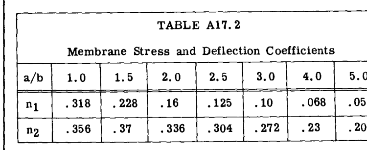

Table A17.2

### A17.7 板の大きなたわみ**

**以下の議論は、主に平坦な外皮パネル上の均一な圧力荷重の支持を扱う問題に関係する。したがって、読者が、飛行艇の船底の外板と隔壁の間に取られた単一の矩形外皮パネルの解析問題に適用される議論を視覚化すれば、アイデアを固定するのに役立つかもしれない。同様に有用なのは、わずかに湾曲した大型の加圧胴体のリングとストリンガーの間の、ほぼ平坦なパネルの図である。

本章の前の条項では、横荷重下のシートパネルの2つの極端なケースの解析結果が概説された。一方の極端では、加えられた荷重に対して曲げ剛性が大きいシート（したがってわずかしかたわまない）は、板曲げ解によって満足に解析され得る。もう一方の極端では、大きなたわみを引き起こすのに十分な大きさの横荷重下の非常に薄いシートは、曲げ剛性が無視される膜として処理され得る。

偶然にも、最も効率的な外板設計は、一般にこれら2つの極端なケースの中間に位置する。一方では、設計者が（通常はとにかく他の理由で存在する）内部補強構造（リング、バルクヘッド、ストリンガーなど）の存在を利用する場合、外皮を「純粋な」板として振る舞うほど重くする必要はない。他方では、外皮を非常に薄くして、すべての圧力荷重を伸びと膜応力の発生によって支持せざるを得ないようにすると、永久変形が生じ、「キルティング」または「ウォッシュボーディング」が発生する。

大きなたわみを受け、それによって横荷重を一部は曲げ抵抗によって、一部は膜作用によって支持する二次元板の正確な解析は非常に複雑である。Art. A17.6のそれと平行する一次元解析は、参考文献1のpp. 4-10に見られる。より洗練された二次元解析は、同じ参考文献のpp. 347-350に示されている。

大きなたわみ板問題の近似解は、平坦な板と膜の解を以下のように足し合わせることによって得ることができる：

式(12)の板曲げ関係を $q$ について解き、それを $q'$ と呼ぶ。

$$q' = \frac{w_{\text{MAX}} E t^3}{\alpha a^4}$$

次に、式(18)の膜関係を $q$ について解き、それを $q''$ と呼ぶ。

$$q'' = \frac{w_{\text{MAX}}^3 E t}{n_1^3 a^4}$$

これら2つの圧力の和が、単に $q$ と呼ばれる全横圧力を与える。

$$q = q' + q''$$

$$q = \frac{1}{\alpha} \frac{E t^3}{a^4} w_{\text{MAX}} + \frac{1}{n_1^3} \frac{E t}{a^4} w_{\text{MAX}}^3 \quad \text{--- (20)}$$

式(20)は、平坦なシートが横荷重を支持できる2つの極端な挙動メカニズムの個々の剛性を足し合わせることに基づいていることがわかる。応力システム間の相互作用は想定されておらず、システムは非線形であるため、結果は近似にしかなり得ない。

式(20)は、次のように書き直すのが最適である。

$$\frac{q a^4}{E t^4} = \frac{1}{\alpha} \left( \frac{w_{\text{MAX}}}{t} \right) + \frac{1}{n_1^3} \left( \frac{w_{\text{MAX}}}{t} \right)^3 \quad \text{--- (21)}$$

Fig. A17.6は、Table A17.1およびA17.2から取得した $\alpha$ および $n_1$ の値を使用して、正方形板についてプロットされた式(21)を示している。また、正確な解析（参考文献5）の結果もプロットされている。見られるように、式(21)は、与えられた圧力に対して大きすぎるたわみを与えるため、いくらか保守的である。

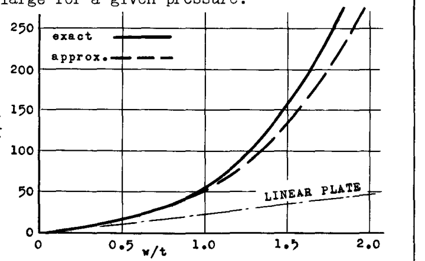

Fig. A17.6

*ただし、式(19)で $n_2 = 0.260$ を使用する。この値は正方形パネルの中心における応力を与えるが、Table A17.2の $n_2 = 0.356$ はパネル端部における応力用である。

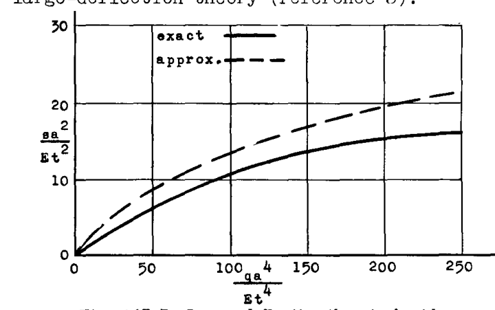

Fig. A17.7

より正確な理論の結果を使用することが明らかに望ましいため、これらのいくつかをTable A17.3に示す。追加のケース（他のタイプの端部支持）の処理は、参考文献6のpp. 221, 222に見られる。

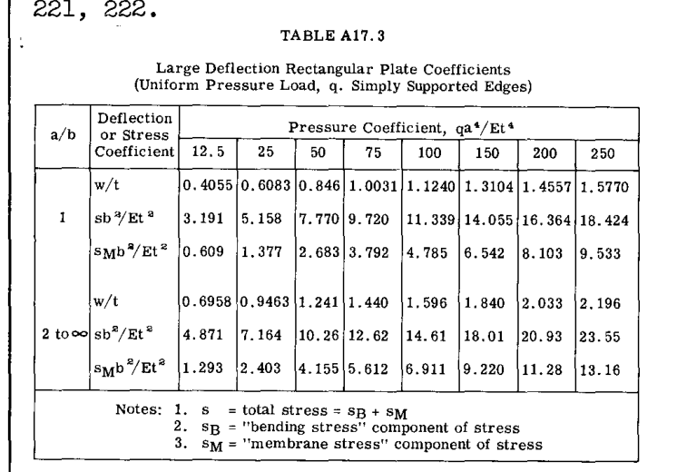

Table A17.3

### A17.8 大きなたわみ板および膜解析の応用における考慮事項

本章を終える前に、船体または胴体内の平坦な圧力パネル解析への応用に関して、上述の展開におけるいくつかの重大な省略に注目することが適切である。大きなたわみ板および膜解析は、板曲げ解析が不十分であると思われる応用分野のために開発された。しかし、これらの解析自体、実際にはめったに遭遇しない条件を前提としていた。

第一に、解析はシートパネルの境界における不屈の支持を想定している。実際には、外皮はストリンガーとバルクヘッドの弾性フレームワークにわたって引き伸ばされている。したがって、大きなたわみ時に発生する重い膜引張力が支持部を互いに向かってたわませ、それによって板のたわみを増加させ、応力の一部を緩和することは当然である。

弾性端部支持を持つ膜ストリップの単純な一次元解析（Art. A17.6の解析に平行）は、フレームワークの弾力性が無視された場合、25%程度の誤差が発生する可能性があることを示している（参考文献7）。本稿執筆時点では、この問題の二次元的な処理は著者に知られていない。

第二に、アナリストが横圧力荷重単独に対してパネルをチェックしなければならないことはめったにない。ほとんどの場合、ストリンガーとバルクヘッドのフレームワーク上のパネルの「視野」全体が、尾翼荷重曲げ応力とキャビン加圧応力からの面内荷重を同時に伝達しなければならない。

大きなたわみ板および膜解析は非線形であるため、単純な重ね合わせによって正確な応力を見つけることはできない。そのような手順によって導入される誤差の大きさは、正確な解析がない場合は推定が困難である。Art. A17.6のそれと平行するが、弾性支持と軸荷重を伴う一次元解析が参考文献7に与えられている。軸荷重の影響が非常に重要であることを示すこれらの結果は、より完全な二次元研究の代わりのガイドとして使用され得る。興味のある読者は、詳細について原著を参照されたい。

## 参考文献

1. Timoshenko, S. “Theory of Plates and Shells”, McGraw-Hill, N. Y., 1940.
2. Den Hartog, J. P. “Advanced Strength of Materials”, McGraw-Hill, N. Y., 1952.
3. Sechler, E. and Dunn, L. “Airplane Structural Analysis and Design”, John Wiley, N. Y., 1942.
4. Heubert, M. and Sommer, A., Rectangular Shell Plating Under Uniformly Distributed Hydrostatic Pressure, NACA TM 965.
5. （選択された大きなたわみ板の参考文献）
   - 1. Moness, E. Flat Plates Under Pressure, Journ. Aero. Sci., 5, Sept. 1938.
   - 2. Ramberg, W., McPherson, A. and Levy, S., Normal Pressure Tests of Rectangular Plates, NACA TR 748, 1942.
   - 3. Levy, S. Square Plate With Clamped Edges Under Normal Pressure Producing Large Deflections, NACA TR 740, 1942.
   - 4. Levy, S. Bending of Rectangular Plates With Large Deflections, NACA TR 737, 1942.
   - 5. Chi-Teh Wang, Nonlinear Large Deflection Boundary-value Problems of Rectangular Plates, NACA TN 1425, 1948.
   - 6. Chi-Teh Wang, Bending of Rectangular Plates With Large Deflections, NACA TN 1462, 1948.
6. Roark, R. J. “Formulas for Stress and Strain”, McGraw-Hill, N. Y. 3rd Edition, 1954.
7. Flugge, W. Stress Problems in Pressurized Cabins, NACA TN 2612, 1952.
8. Engineering Research Bulletins of Oklahoma State University.
   - 1. No. 15. Influence Coefficients for Circular Plates.
   - 2. No. 17. Analysis of Thin Plates Supported on their Corners.
   - 3. No. 118. Analysis of Flat Plates by Algebraic Carryover Method.